# Housing

Amaia Telleria

2024-05-28

```r
# Install and load necessary packages
library(ggplot2)
library(dplyr)
library(tidyr)
```

Cargar los datos

```r
# Load the data from a CSV file named "Housing.csv"
housing_data <- read.csv("Housing.csv")

# View the first few rows of the dataset to confirm it's loaded correctly
head(housing_data)
```

```
##      price area bedrooms bathrooms stories mainroad guestroom basement
## 1 13300000 7420        4         2       3      yes        no       no
## 2 12250000 8960        4         4       4      yes        no       no
## 3 12250000 9960        3         2       2      yes        no      yes
## 4 12215000 7500        4         2       2      yes        no      yes
## 5 11410000 7420        4         1       2      yes       yes      yes
## 6 10850000 7500        3         3       1      yes        no      yes
##   hotwaterheating airconditioning parking prefarea furnishingstatus
## 1              no             yes       2      yes        furnished
## 2              no             yes       3       no        furnished
## 3              no              no       2      yes   semi-furnished
## 4              no             yes       3      yes        furnished
## 5              no             yes       2       no        furnished
## 6              no             yes       2      yes   semi-furnished
```

Summary datos sin caracteristicas asignadas

```r
summary(housing_data)
```

```
##      price               area          bedrooms       bathrooms
##  Min.   : 1750000   Min.   : 1650   Min.   :1.000   Min.   :1.000
##  1st Qu.: 3430000   1st Qu.: 3600   1st Qu.:2.000   1st Qu.:1.000
##  Median : 4340000   Median : 4600   Median :3.000   Median :1.000
##  Mean   : 4766729   Mean   : 5151   Mean   :2.965   Mean   :1.286
##  3rd Qu.: 5740000   3rd Qu.: 6360   3rd Qu.:3.000   3rd Qu.:2.000
##  Max.   :13300000   Max.   :16200   Max.   :6.000   Max.   :4.000
##     stories        mainroad          guestroom           basement
##  Min.   :1.000   Length:545         Length:545         Length:545
##  1st Qu.:1.000   Class :character   Class :character   Class :character
##  Median :2.000   Mode  :character   Mode  :character   Mode  :character
##  Mean   :1.806
##  3rd Qu.:2.000
##  Max.   :4.000
##  hotwaterheating    airconditioning       parking         prefarea
##  Length:545         Length:545         Min.   :0.0000   Length:545
##  Class :character   Class :character   1st Qu.:0.0000   Class :character
##  Mode  :character   Mode  :character   Median :0.0000   Mode  :character
##                                        Mean   :0.6936
##                                        3rd Qu.:1.0000
##                                        Max.   :3.0000
##  furnishingstatus
##  Length:545
##  Class :character
##  Mode  :character
##
##
##
```

Matriz de correlacion sin caracteristicas asignadas

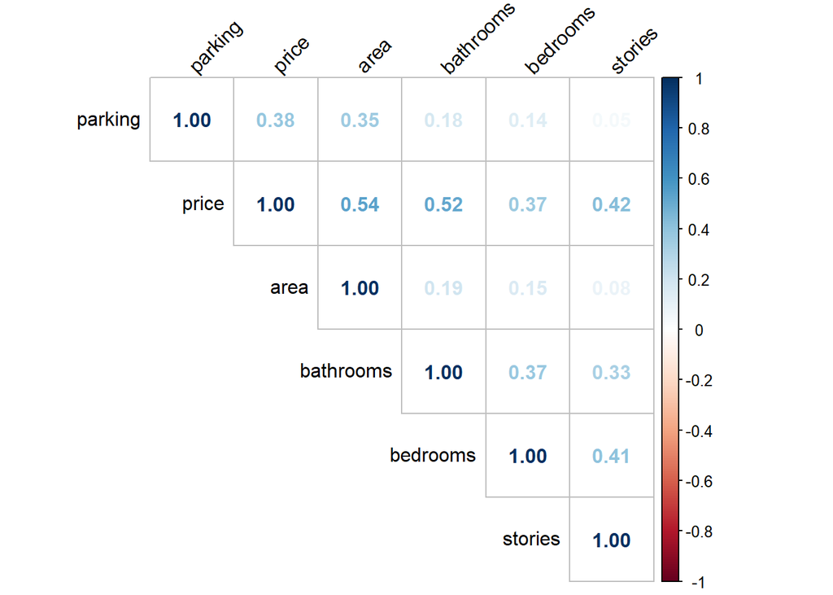

```r
# Install and load necessary packages
if (!requireNamespace("corrplot", quietly = TRUE)) {
    install.packages("corrplot")
}
library(corrplot)
# Assuming housing_data is your dataframe
# Select only numeric variables
numeric_data <- housing_data %>% select(where(is.numeric))

# Calculate the correlation matrix
cor_matrix <- cor(numeric_data, use = "pairwise.complete.obs")  # handling NAs appropriately

# Visualize the correlation matrix with numeric values
corrplot(cor_matrix, method = "number", type = "upper", order = "hclust",
         tl.col = "black", tl.srt = 45,  # Text label options
         addCoef.col = "red")  # Color of the correlation coefficients
```

En R, la diferencia principal entre los tipos de datos entero, numérico y factor radica en cómo representan y manejan los datos, así como en su uso previsto:

### Entero

- **Definición**: El tipo de dato entero representa números enteros sin puntos decimales.
- **Uso**: Normalmente se utiliza para conteos, índices o cualquier dato que naturalmente se clasifique como números enteros.
- **Operaciones**: Soporta operaciones aritméticas y se puede usar en cálculos matemáticos.
- **Ejemplo**: `1`, `42`, `-5`

### Numérico

- **Definición**: El tipo de dato numérico (también conocido como doble o real) representa números que pueden contener puntos decimales.
- **Uso**: Se utiliza para datos continuos, mediciones y cualquier dato que requiera precisión decimal.
- **Operaciones**: Soporta operaciones aritméticas, funciones matemáticas y es adecuado para análisis estadístico.
- **Ejemplo**: `3.14`, `-0.001`, `100.0`

### Factor

- **Definición**: El tipo de dato factor representa datos categóricos y los almacena como enteros con niveles correspondientes.
- **Uso**: Se utiliza para variables categóricas que tienen un número fijo de valores distintos o niveles, como etiquetas, categorías o clasificaciones.
- **Operaciones**: Adecuado para modelado estadístico, especialmente en modelos de regresión y análisis de varianza, donde los datos categóricos necesitan ser codificados como factores.
- **Ejemplo**: `factor(c("bajo", "medio", "alto"))` donde `bajo`, `medio` y `alto` son los niveles.

### Comparación Detallada

#### Entero vs Numérico

- **Almacenamiento**: Los enteros se almacenan como números enteros, mientras que los numéricos pueden almacenar tanto números enteros como decimales.
- **Precisión**: Los numéricos se utilizan cuando es necesaria la precisión con puntos decimales, mientras que los enteros se utilizan para números enteros exactos.
- **Ejemplo de Uso**:
  - Entero: Contar elementos (e.g., número de dormitorios).
  - Numérico: Medir cantidades (e.g., precio, área).

#### Numérico vs Factor

- **Naturaleza de los Datos**: Los numéricos se utilizan para datos continuos, mientras que los factores se utilizan para datos categóricos.
- **Operaciones**: Los numéricos permiten operaciones aritméticas, mientras que los factores se utilizan para agrupación y clasificación.
- **Ejemplo de Uso**:
  - Numérico: `100.5`, `3.14` (datos continuos como mediciones).
  - Factor: `"Masculino"`, `"Femenino"` (categorías para agrupación).

#### Entero vs Factor

- **Naturaleza de los Datos**: Los enteros son valores numéricos utilizados para conteo, mientras que los factores representan datos categóricos.
- **Operaciones**: Los enteros pueden ser utilizados en cálculos matemáticos, mientras que los factores se utilizan para agrupación y clasificación.
- **Ejemplo de Uso**:
  - Entero: `3`, `5`, `7` (datos discretos como conteos).
  - Factor: `"bajo"`, `"medio"`, `"alto"` (categorías con niveles).

Caracteristicas asignadas

```r
# Load necessary library
library(dplyr)


# Convert each column to the appropriate data type
housing_data <- housing_data %>%
  mutate(
    price = as.numeric(price),                      # Numeric
    area = as.numeric(area),                        # Numeric
    bedrooms = as.integer(bedrooms),                # Discrete Numeric
    bathrooms = as.integer(bathrooms),              # Discrete Numeric
    stories = as.integer(stories),                  # Discrete Numeric
    mainroad = factor(mainroad, levels = c("no", "yes")),  # Categorical (Yes/No)
    guestroom = factor(guestroom, levels = c("no", "yes")), # Categorical (Yes/No)
    basement = factor(basement, levels = c("no", "yes")),   # Categorical (Yes/No)
    hotwaterheating = factor(hotwaterheating, levels = c("no", "yes")), # Categorical (Yes/No)
    airconditioning = factor(airconditioning, levels = c("no", "yes")), # Categorical (Yes/No)
    parking = as.integer(parking),                  # Discrete Numeric
    prefarea = factor(prefarea, levels = c("no", "yes")), # Categorical (Yes/No)
    furnishingstatus = factor(furnishingstatus, levels = c("unfurnished", "semi-furnished", "furnished")) # Categorical (Label)
  )

summary(housing_data)
```

```
##      price               area          bedrooms       bathrooms
##  Min.   : 1750000   Min.   : 1650   Min.   :1.000   Min.   :1.000
##  1st Qu.: 3430000   1st Qu.: 3600   1st Qu.:2.000   1st Qu.:1.000
##  Median : 4340000   Median : 4600   Median :3.000   Median :1.000
##  Mean   : 4766729   Mean   : 5151   Mean   :2.965   Mean   :1.286
##  3rd Qu.: 5740000   3rd Qu.: 6360   3rd Qu.:3.000   3rd Qu.:2.000
##  Max.   :13300000   Max.   :16200   Max.   :6.000   Max.   :4.000
##     stories      mainroad  guestroom basement  hotwaterheating airconditioning
##  Min.   :1.000   no : 77   no :448   no :354   no :520         no :373
##  1st Qu.:1.000   yes:468   yes: 97   yes:191   yes: 25         yes:172
##  Median :2.000
##  Mean   :1.806
##  3rd Qu.:2.000
##  Max.   :4.000
##     parking       prefarea        furnishingstatus
##  Min.   :0.0000   no :417   unfurnished   :178
##  1st Qu.:0.0000   yes:128   semi-furnished:227
##  Median :0.0000             furnished     :140
##  Mean   :0.6936
##  3rd Qu.:1.0000
##  Max.   :3.0000
```

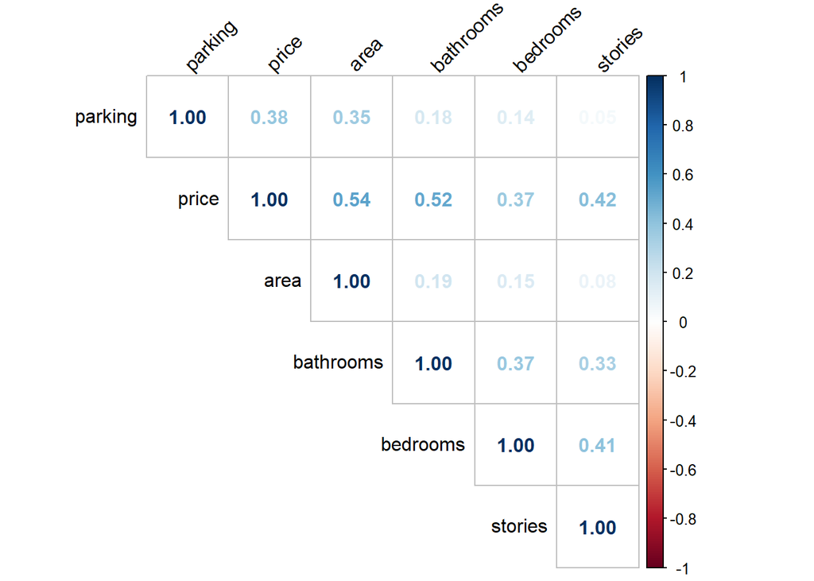

```r
# Install and load necessary packages
if (!requireNamespace("corrplot", quietly = TRUE)) {
    install.packages("corrplot")
}
library(corrplot)

# Assuming housing_data is your dataframe
# Select only numeric variables
numeric_data <- housing_data %>% select(where(is.numeric))

# Calculate the correlation matrix
cor_matrix <- cor(numeric_data, use = "pairwise.complete.obs")  # handling NAs appropriately

# Visualize the correlation matrix with numeric values
corrplot(cor_matrix, method = "number", type = "upper", order = "hclust",
         tl.col = "black", tl.srt = 45,  # Text label options
         addCoef.col = "red")  # Color of the correlation coefficients
```

Caracteristicas asignadas como factores

```r
# Load necessary library
library(dplyr)


# Convert each column to the appropriate data type
housing_data <- housing_data %>%
  mutate(
    price = as.numeric(price),                      # Numeric
    area = as.numeric(area),                        # Numeric
    bedrooms = as.factor(bedrooms),                # Discrete Numeric
    bathrooms = as.factor(bathrooms),              # Discrete Numeric
    stories = as.factor(stories),                  # Discrete Numeric
    mainroad = factor(mainroad, levels = c("no", "yes")),  # Categorical (Yes/No)
    guestroom = factor(guestroom, levels = c("no", "yes")), # Categorical (Yes/No)
    basement = factor(basement, levels = c("no", "yes")),   # Categorical (Yes/No)
    hotwaterheating = factor(hotwaterheating, levels = c("no", "yes")), # Categorical (Yes/No)
    airconditioning = factor(airconditioning, levels = c("no", "yes")), # Categorical (Yes/No)
    parking = as.factor(parking),                  # Discrete Numeric
    prefarea = factor(prefarea, levels = c("no", "yes")), # Categorical (Yes/No)
    furnishingstatus = factor(furnishingstatus, levels = c("unfurnished", "semi-furnished", "furnished")) # Categorical (Label)
  )

summary(housing_data)
```

```
##      price               area       bedrooms bathrooms stories mainroad
##  Min.   : 1750000   Min.   : 1650   1:  2    1:401     1:227   no : 77
##  1st Qu.: 3430000   1st Qu.: 3600   2:136    2:133     2:238   yes:468
##  Median : 4340000   Median : 4600   3:300    3: 10     3: 39
##  Mean   : 4766729   Mean   : 5151   4: 95    4:  1     4: 41
##  3rd Qu.: 5740000   3rd Qu.: 6360   5: 10
##  Max.   :13300000   Max.   :16200   6:  2
##  guestroom basement  hotwaterheating airconditioning parking prefarea
##  no :448   no :354   no :520         no :373         0:299   no :417
##  yes: 97   yes:191   yes: 25         yes:172         1:126   yes:128
##                                                      2:108
##                                                      3: 12
##
##
##        furnishingstatus
##  unfurnished   :178
##  semi-furnished:227
##  furnished     :140
##
##
##
```

```r
# Install and load necessary packages
if (!requireNamespace("corrplot", quietly = TRUE)) {
    install.packages("corrplot")
}
library(corrplot)

# Assuming housing_data is your dataframe
# Select only numeric variables
numeric_data <- housing_data %>% select(where(is.numeric))

# Calculate the correlation matrix
cor_matrix <- cor(numeric_data, use = "pairwise.complete.obs")  # handling NAs appropriately

print(cor_matrix)
```

```
##           price      area
## price 1.0000000 0.5359973
## area  0.5359973 1.0000000
```

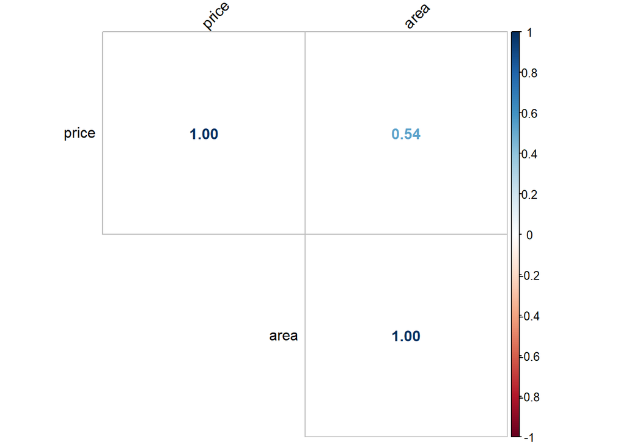

```r
# Visualize the correlation matrix with numeric values
corrplot(cor_matrix, method = "number", type = "upper", order = "hclust",
         tl.col = "black", tl.srt = 45,  # Text label options
         addCoef.col = "red")  # Color of the correlation coefficients
```

Boxplots de todas las caracteristicas respecto a el precio

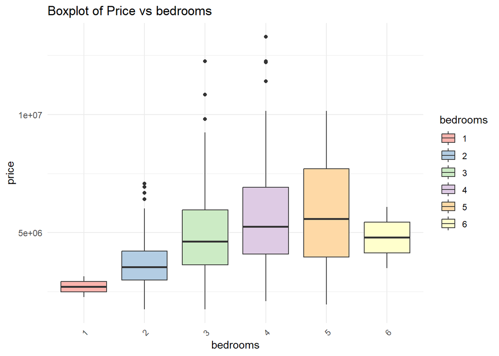

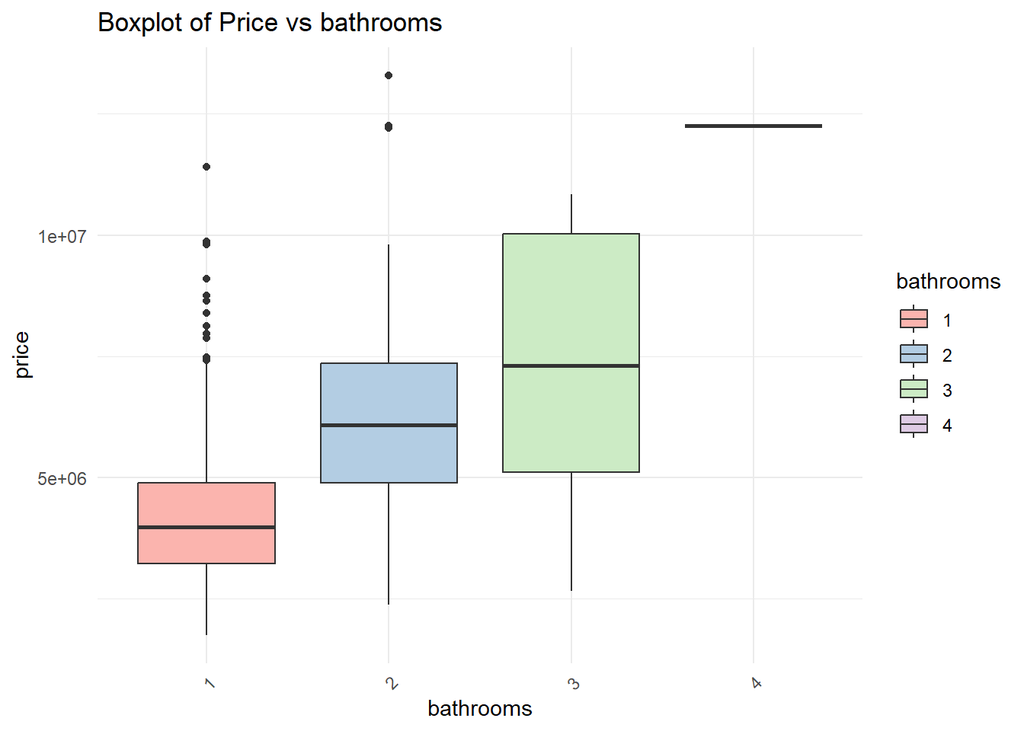

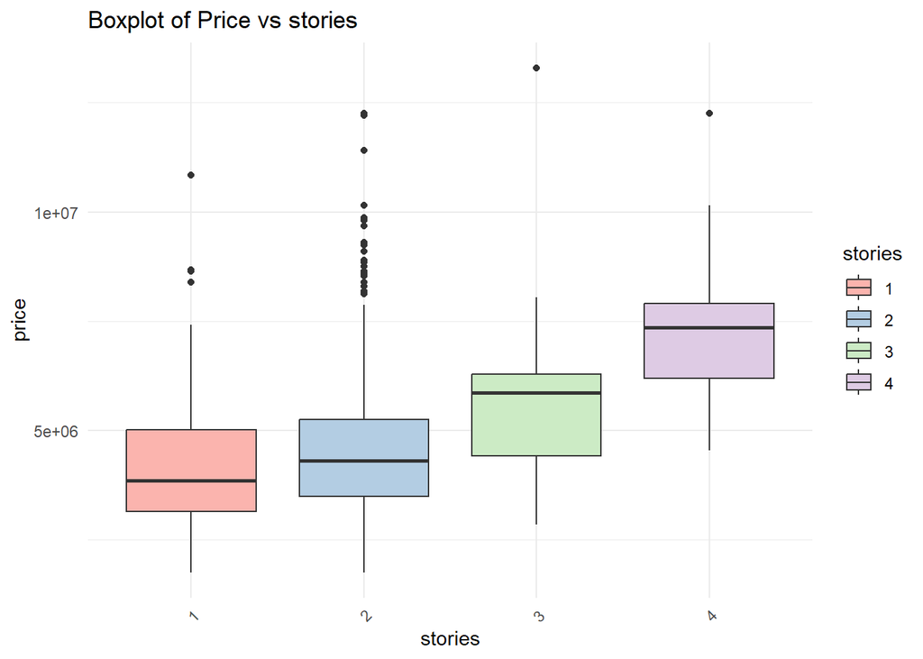

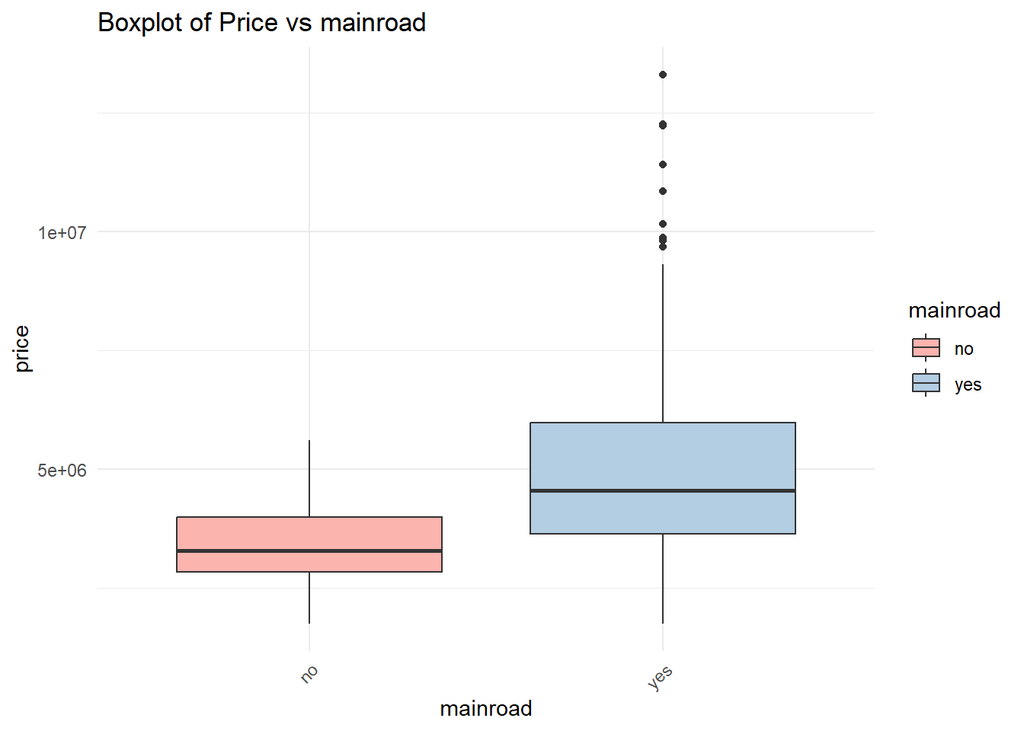

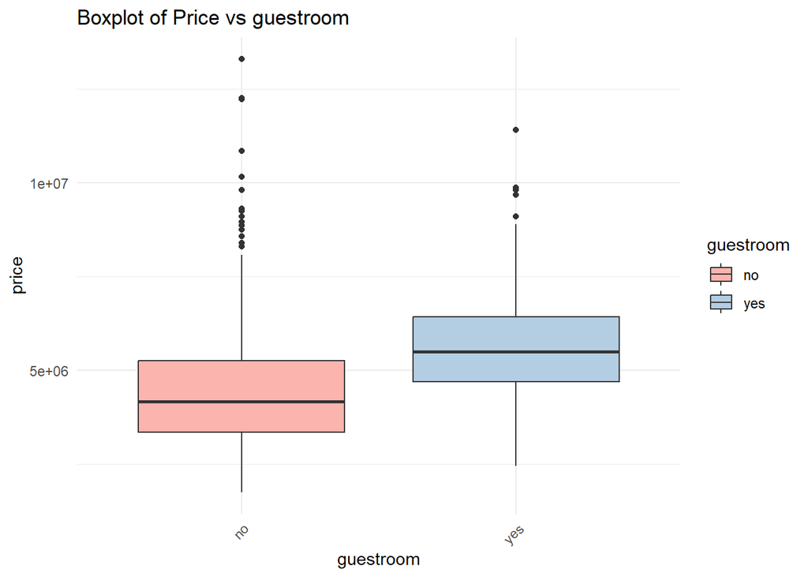

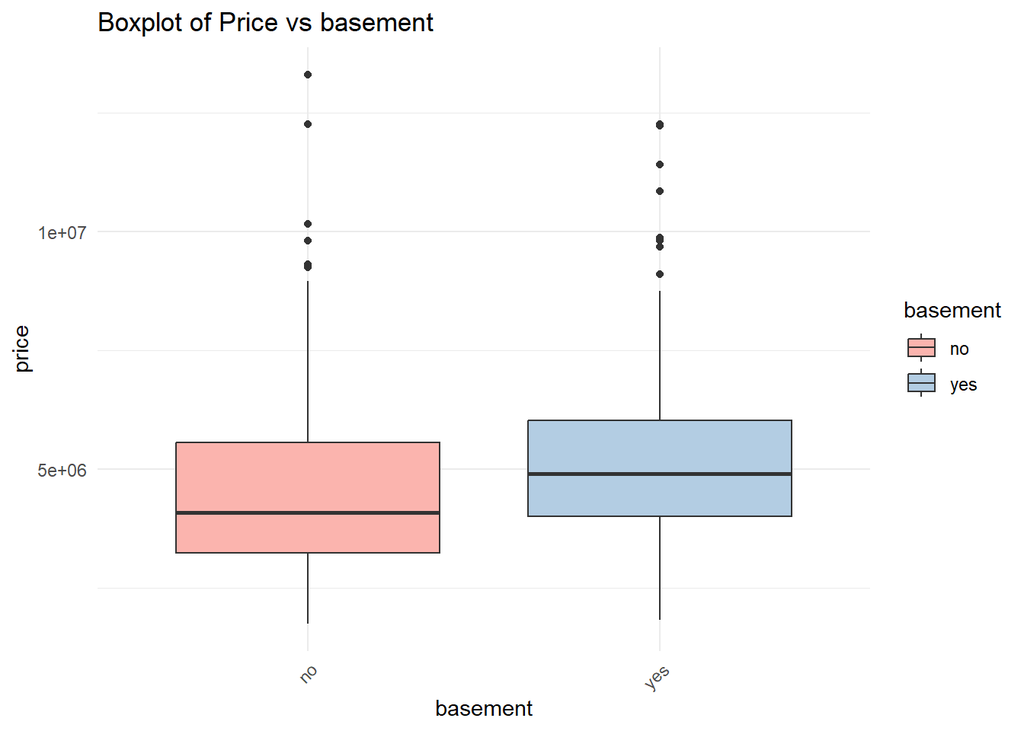

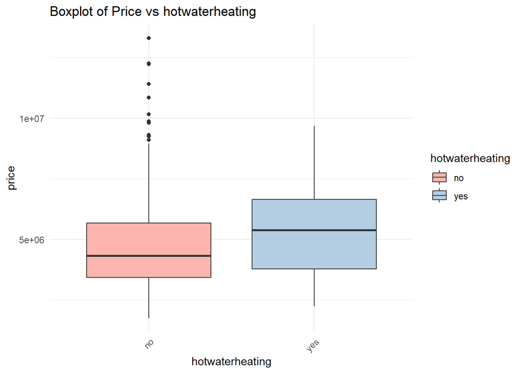

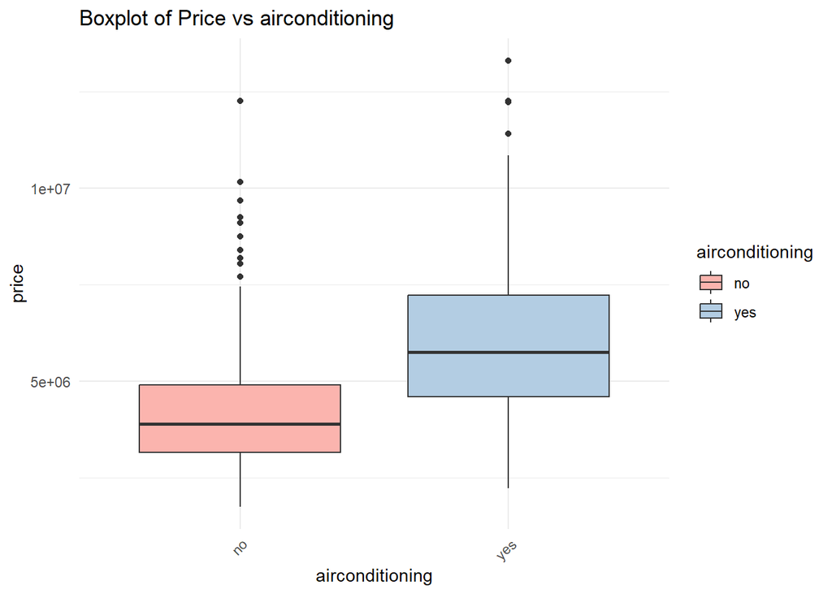

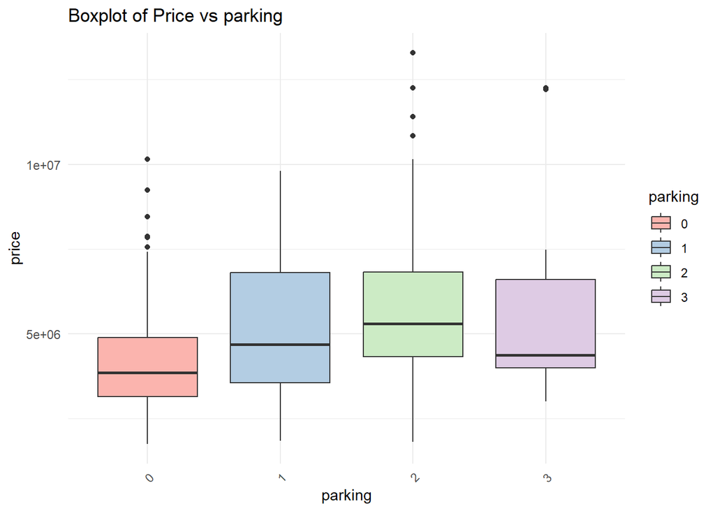

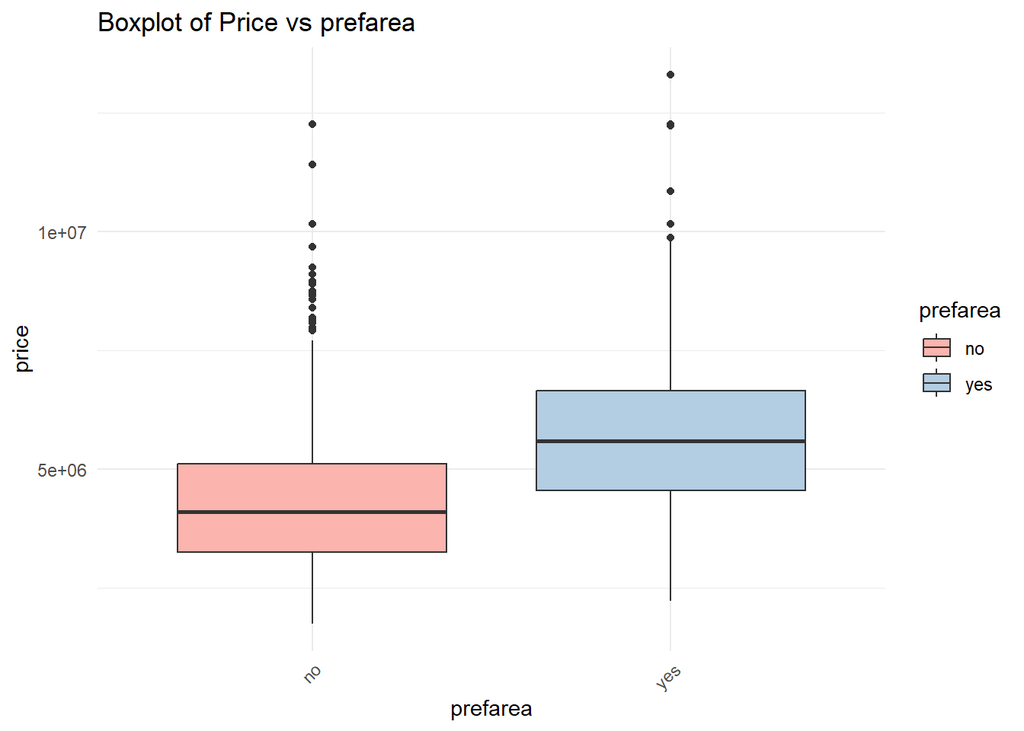

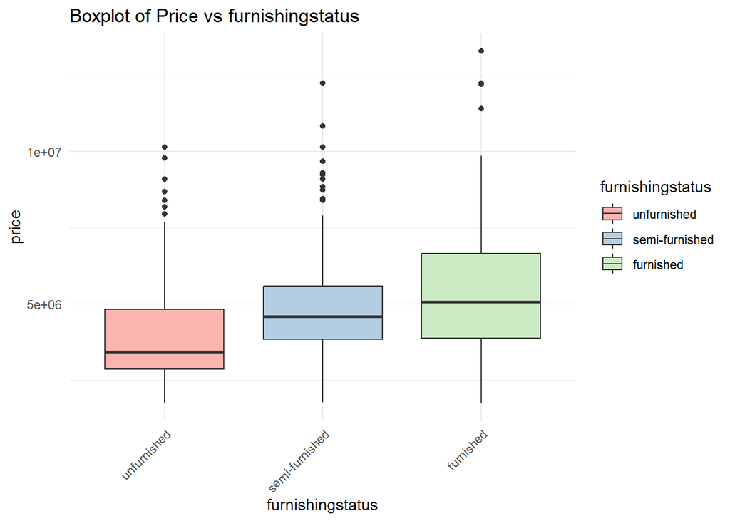

```r
# Load necessary libraries
if (!requireNamespace("ggplot2", quietly = TRUE)) {
    install.packages("ggplot2")
}
library(ggplot2)
library(dplyr)

non_numeric_columns <- housing_data %>%
  select(where(~ !is.numeric(.)))

# Create a function to plot boxplots for non-numeric columns against price
create_boxplots <- function(data, non_numeric_cols, numeric_col) {
  for (col in names(non_numeric_cols)) {
    p <- ggplot(data, aes_string(x = col, y = numeric_col, fill = col)) +
      geom_boxplot() +
      labs(title = paste("Boxplot of Price vs", col), x = col, y = numeric_col) +
      theme_minimal() +
      scale_fill_brewer(palette = "Pastel1") +
      theme(axis.text.x = element_text(angle = 45, hjust = 1))
    print(p)
  }
}

# Call the function to create boxplots
create_boxplots(housing_data, non_numeric_columns, "price")
```

Grafico de puntos de correlacion entre area y precio con cada caracteristica representada

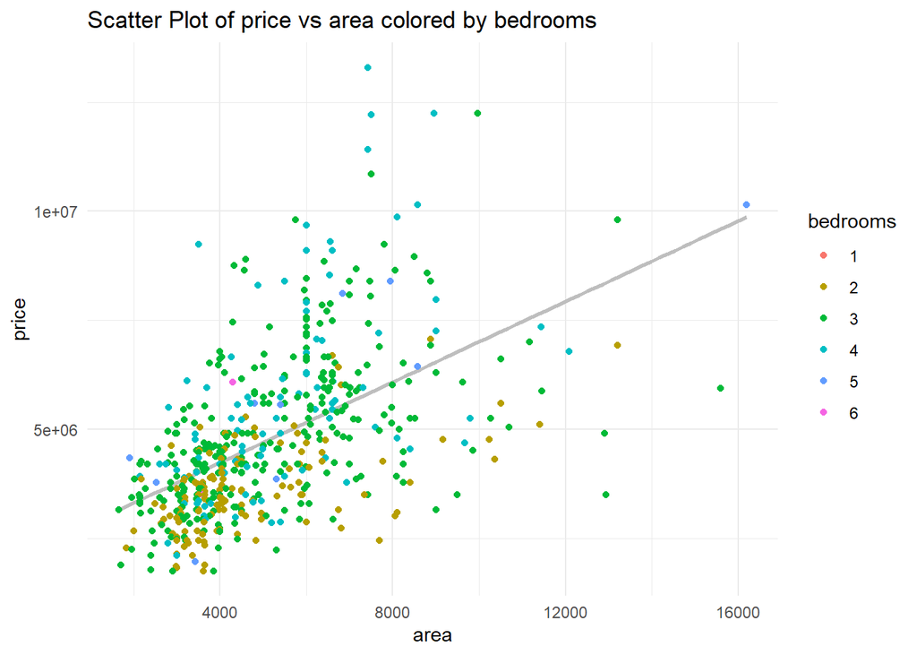

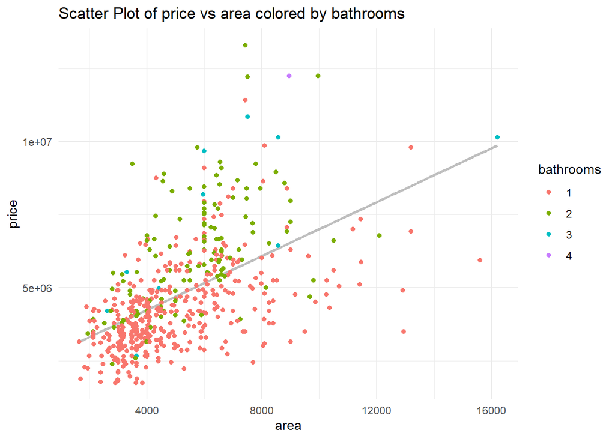

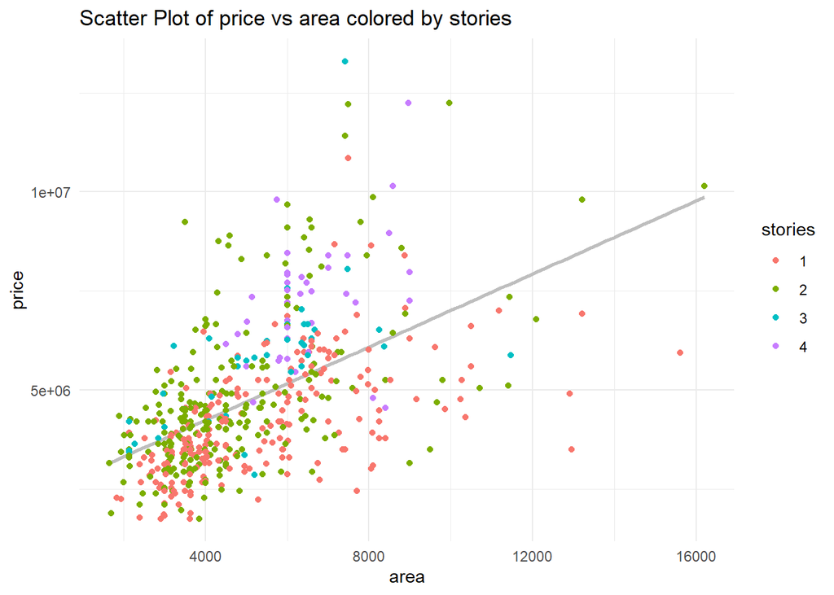

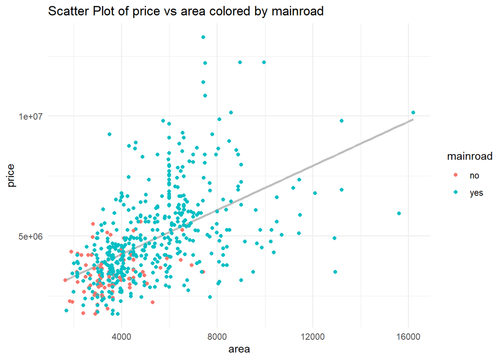

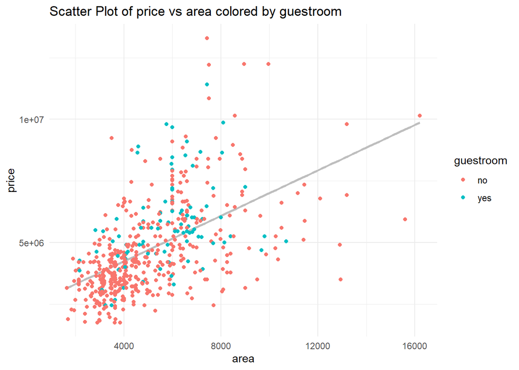

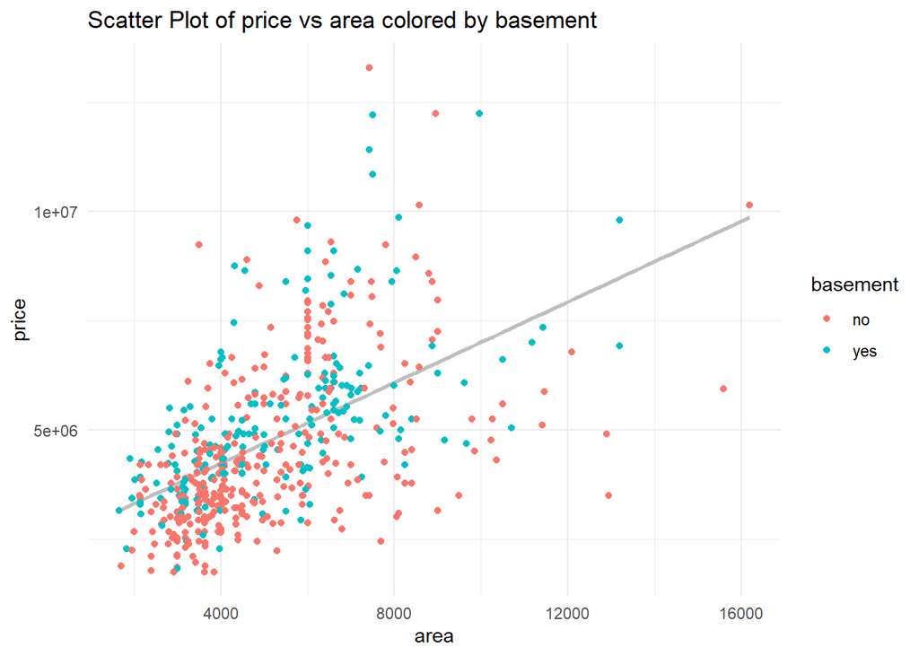

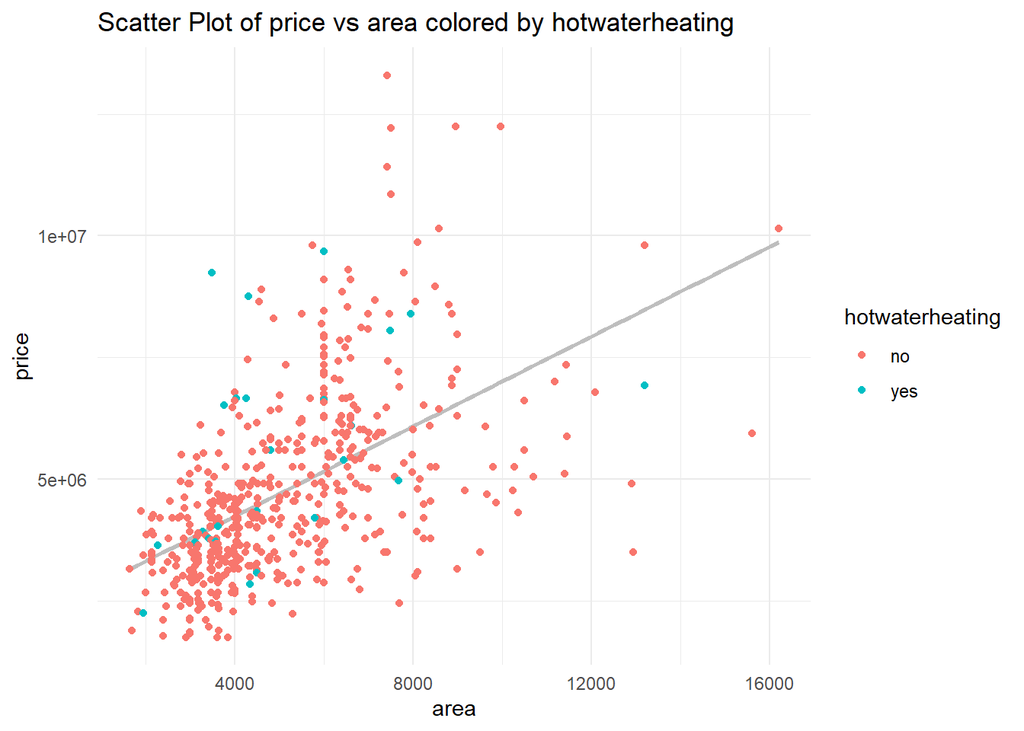

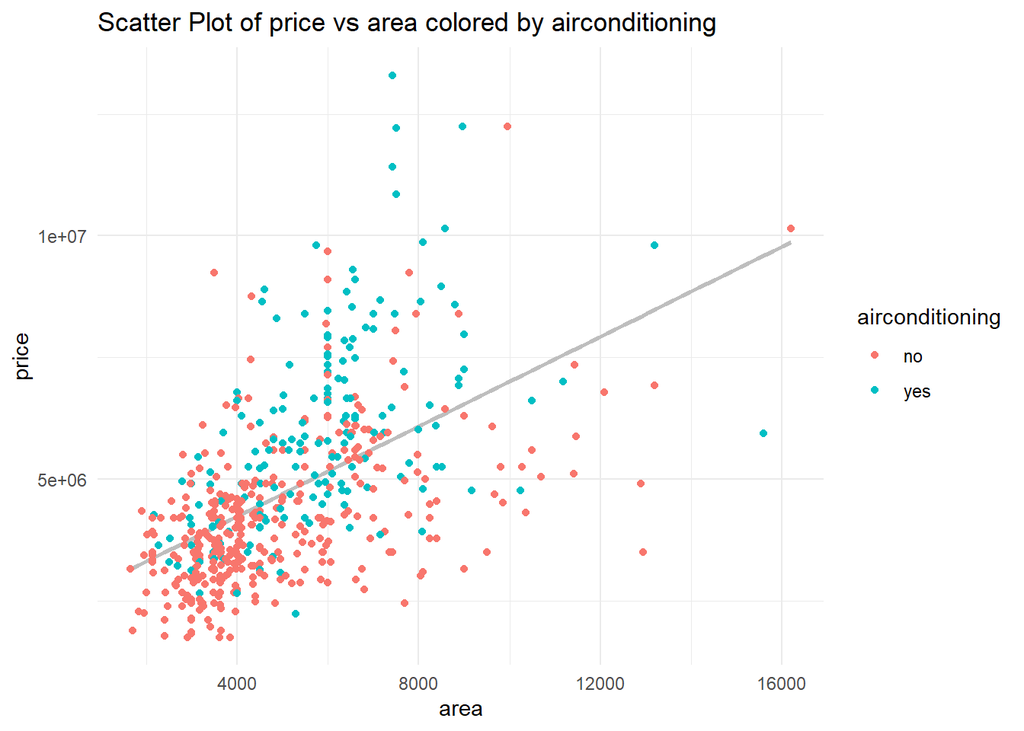

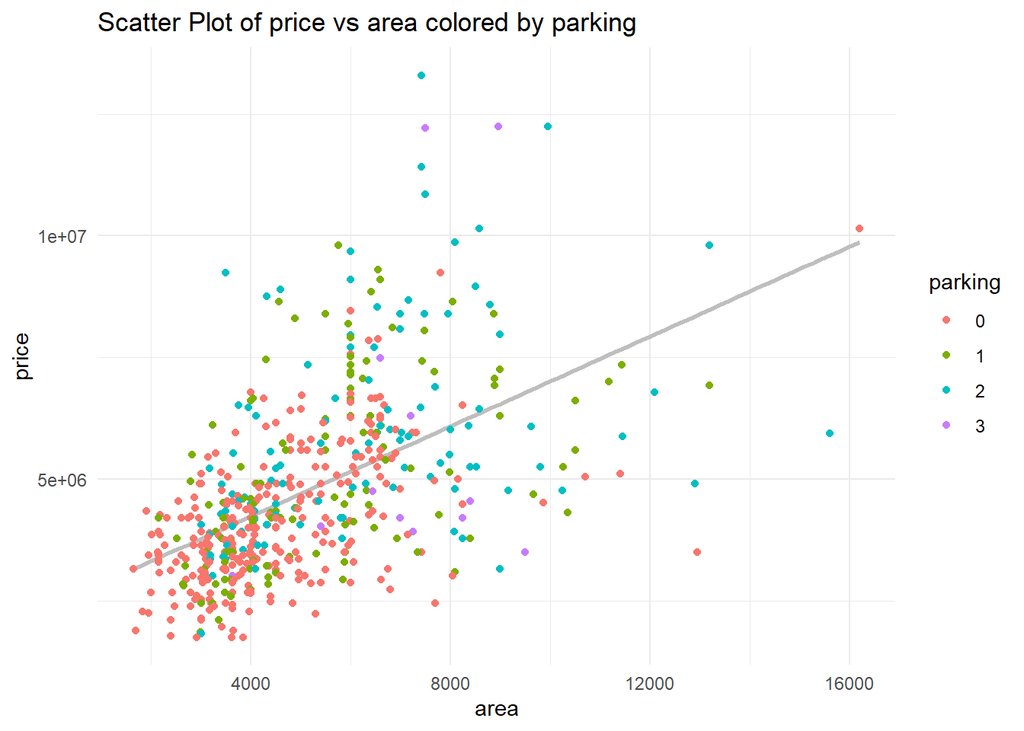

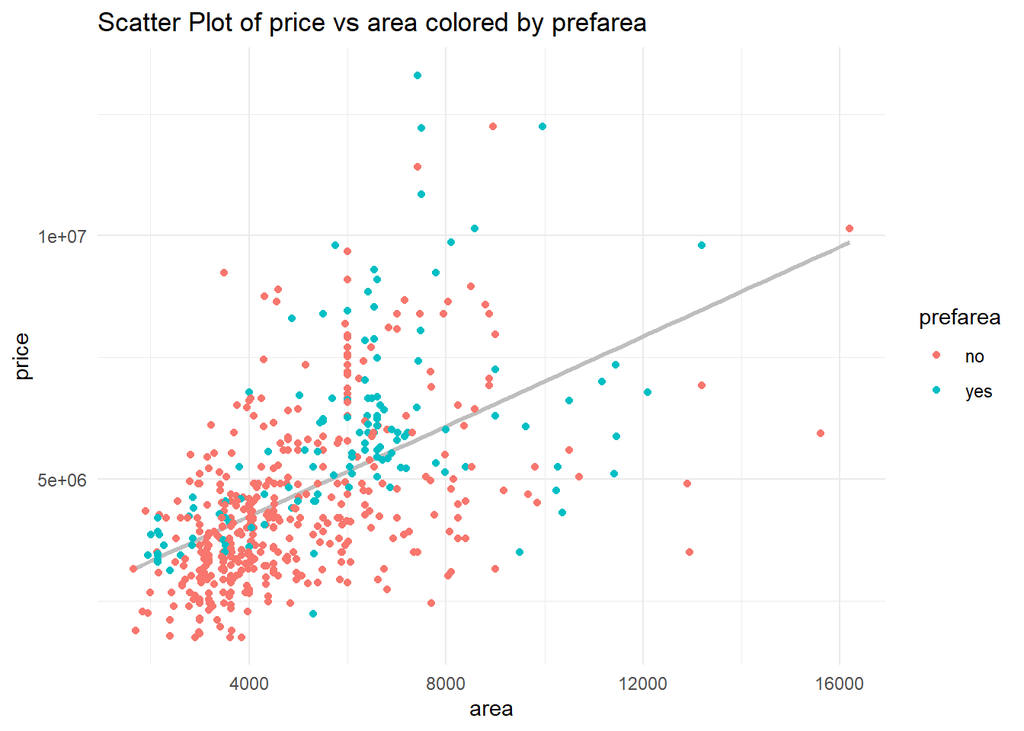

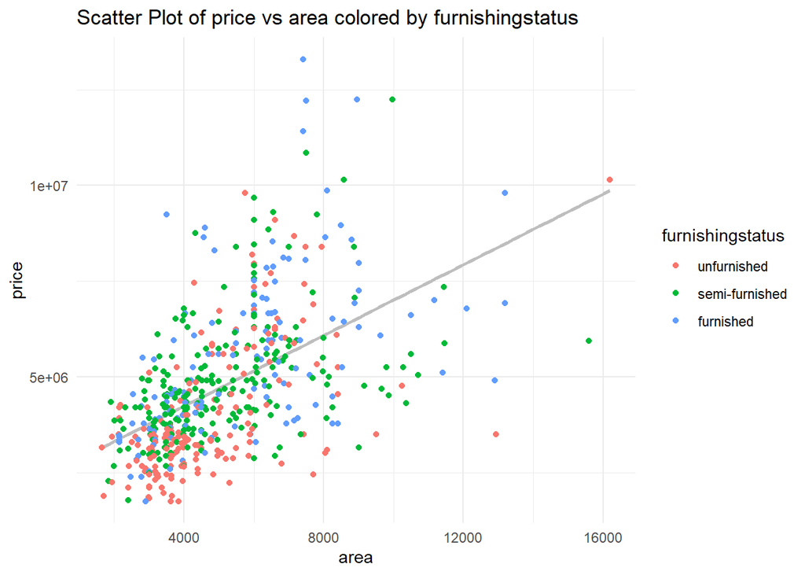

```r
# Install and load necessary libraries
if (!requireNamespace("ggplot2", quietly = TRUE)) {
    install.packages("ggplot2")
}

library(ggplot2)
library(dplyr)



# Identify non-numeric columns (excluding 'price' and 'area')
non_numeric_columns <- housing_data %>%
  select(where(~ !is.numeric(.)))

# Create a function to plot scatter plots with color based on factor variables
create_scatter_plots <- function(data, non_numeric_cols, x_col, y_col) {
  for (col in names(non_numeric_cols)) {
    p <- ggplot(data, aes_string(x = x_col, y = y_col, color = col)) +
      geom_smooth(method = "lm", se = FALSE, color = "grey")  +  # Added grey color to trend line for clarity
      geom_point() +
      labs(title = paste("Scatter Plot of", y_col, "vs", x_col, "colored by", col),
           x = x_col, y = y_col) +
      theme_minimal()
    print(p)
  }
}

# Call the function to create scatter plots
create_scatter_plots(housing_data, non_numeric_columns, "area", "price")
```

Conversion de todas las caracteristicas a formato numerico

```r
# Install and load necessary packages
if (!requireNamespace("corrplot", quietly = TRUE)) {
    install.packages("corrplot")
}
library(corrplot)

housing_data <- housing_data %>%
  mutate(
    price = as.numeric(price),                      # Numeric
    area = as.numeric(area),                        # Numeric
    bedrooms = as.numeric(bedrooms),                # Numeric (treated as discrete numeric)
    bathrooms = as.numeric(bathrooms),              # Numeric (treated as discrete numeric)
    stories = as.numeric(stories),                  # Numeric (treated as discrete numeric)
    mainroad = as.numeric(factor(mainroad, levels = c("no", "yes"))),  # Convert factor to numeric
    guestroom = as.numeric(factor(guestroom, levels = c("no", "yes"))), # Convert factor to numeric
    basement = as.numeric(factor(basement, levels = c("no", "yes"))),   # Convert factor to numeric
    hotwaterheating = as.numeric(factor(hotwaterheating, levels = c("no", "yes"))), # Convert factor to numeric
    airconditioning = as.numeric(factor(airconditioning, levels = c("no", "yes"))), # Convert factor to numeric
    parking = as.numeric(parking),                  # Numeric (treated as discrete numeric)
    prefarea = as.numeric(factor(prefarea, levels = c("no", "yes"))), # Convert factor to numeric
    furnishingstatus = as.numeric(factor(furnishingstatus, levels = c("unfurnished", "semi-furnished", "furnished"))) # Convert factor to numeric
  )

# Display the updated dataframe structure
str(housing_data)
```

```
## 'data.frame':    545 obs. of  13 variables:
##  $ price           : num  13300000 12250000 12250000 12215000 11410000 ...
##  $ area            : num  7420 8960 9960 7500 7420 7500 8580 16200 8100 5750 ...
##  $ bedrooms        : num  4 4 3 4 4 3 4 5 4 3 ...
##  $ bathrooms       : num  2 4 2 2 1 3 3 3 1 2 ...
##  $ stories         : num  3 4 2 2 2 1 4 2 2 4 ...
##  $ mainroad        : num  2 2 2 2 2 2 2 2 2 2 ...
##  $ guestroom       : num  1 1 1 1 2 1 1 1 2 2 ...
##  $ basement        : num  1 1 2 2 2 2 1 1 2 1 ...
##  $ hotwaterheating : num  1 1 1 1 1 1 1 1 1 1 ...
##  $ airconditioning : num  2 2 1 2 2 2 2 1 2 2 ...
##  $ parking         : num  3 4 3 4 3 3 3 1 3 2 ...
##  $ prefarea        : num  2 1 2 2 1 2 2 1 2 2 ...
##  $ furnishingstatus: num  3 3 2 3 3 2 2 1 3 1 ...
```

```r
# Install and load necessary packages
if (!requireNamespace("corrplot", quietly = TRUE)) {
    install.packages("corrplot")
}
library(corrplot)

# Assuming housing_data is your dataframe
# Select only numeric variables
numeric_data <- housing_data %>% select(where(is.numeric))

# Calculate the correlation matrix
cor_matrix <- cor(numeric_data, use = "pairwise.complete.obs")  # handling NAs appropriately

print(cor_matrix)
```

```
##                       price         area    bedrooms  bathrooms     stories
## price            1.00000000  0.535997346  0.36649403 0.51754534  0.42071237
## area             0.53599735  1.000000000  0.15185849 0.19381953  0.08399605
## bedrooms         0.36649403  0.151858486  1.00000000 0.37393024  0.40856424
## bathrooms        0.51754534  0.193819531  0.37393024 1.00000000  0.32616471
## stories          0.42071237  0.083996051  0.40856424 0.32616471  1.00000000
## mainroad         0.29689849  0.288874114 -0.01203324 0.04239762  0.12170613
## guestroom        0.25551729  0.140296590  0.08054870 0.12646884  0.04353767
## basement         0.18705660  0.047416989  0.09731242 0.10210571 -0.17239362
## hotwaterheating  0.09307284 -0.009229236  0.04604889 0.06715910  0.01884651
## airconditioning  0.45295408  0.222393104  0.16060326 0.18691503  0.29360200
## parking          0.38439365  0.352980481  0.13926990 0.17749582  0.04554709
## prefarea         0.32977705  0.234778798  0.07902306 0.06347174  0.04442487
## furnishingstatus 0.30472146  0.171445361  0.12324400 0.14355950  0.10467233
##                     mainroad   guestroom     basement hotwaterheating
## price             0.29689849  0.25551729  0.187056598     0.093072844
## area              0.28887411  0.14029659  0.047416989    -0.009229236
## bedrooms         -0.01203324  0.08054870  0.097312424     0.046048887
## bathrooms         0.04239762  0.12646884  0.102105706     0.067159096
## stories           0.12170613  0.04353767 -0.172393617     0.018846511
## mainroad          1.00000000  0.09233692  0.044002081    -0.011781490
## guestroom         0.09233692  1.00000000  0.372065708    -0.010307884
## basement          0.04400208  0.37206571  1.000000000     0.004384836
## hotwaterheating  -0.01178149 -0.01030788  0.004384836     1.000000000
## airconditioning   0.10542300  0.13817877  0.047341189    -0.130022833
## parking           0.20443255  0.03746575  0.051497175     0.067863888
## prefarea          0.19987578  0.16089694  0.228082853    -0.059411382
## furnishingstatus  0.15672586  0.11832757  0.112830732     0.031628204
##                  airconditioning    parking    prefarea furnishingstatus
## price                 0.45295408 0.38439365  0.32977705        0.3047215
## area                  0.22239310 0.35298048  0.23477880        0.1714454
## bedrooms              0.16060326 0.13926990  0.07902306        0.1232440
## bathrooms             0.18691503 0.17749582  0.06347174        0.1435595
## stories               0.29360200 0.04554709  0.04442487        0.1046723
## mainroad              0.10542300 0.20443255  0.19987578        0.1567259
## guestroom             0.13817877 0.03746575  0.16089694        0.1183276
## basement              0.04734119 0.05149718  0.22808285        0.1128307
## hotwaterheating      -0.13002283 0.06786389 -0.05941138        0.0316282
## airconditioning       1.00000000 0.15917268  0.11738210        0.1504773
## parking               0.15917268 1.00000000  0.09162706        0.1775386
## prefarea              0.11738210 0.09162706  1.00000000        0.1076860
## furnishingstatus      0.15047729 0.17753861  0.10768597        1.0000000
```

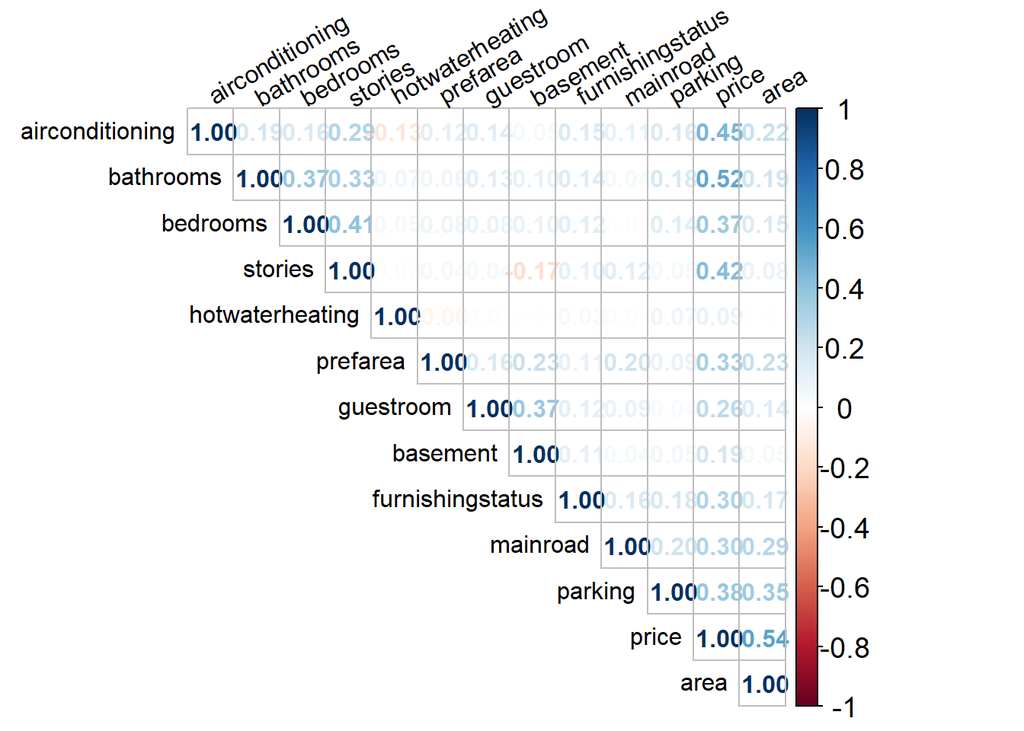

```r
# Visualize the correlation matrix with numeric values
corrplot(cor_matrix, method = "number", type = "upper", order = "hclust",
         tl.col = "black", tl.srt = 30,  # Text label options
         addCoef.col = "red",  # Color of the correlation coefficients
         number.cex = 1,     # Adjust the size of the numbers
         tl.cex = 1,         # Adjust the size of the text labels
         cl.cex = 1.2)         # Adjust the size of the color legend text
```

```r
# Calculate the correlation matrix
cor_matrix <- cor(housing_data, use = "pairwise.complete.obs")

print(cor_matrix)
```

```
##                       price         area    bedrooms  bathrooms     stories
## price            1.00000000  0.535997346  0.36649403 0.51754534  0.42071237
## area             0.53599735  1.000000000  0.15185849 0.19381953  0.08399605
## bedrooms         0.36649403  0.151858486  1.00000000 0.37393024  0.40856424
## bathrooms        0.51754534  0.193819531  0.37393024 1.00000000  0.32616471
## stories          0.42071237  0.083996051  0.40856424 0.32616471  1.00000000
## mainroad         0.29689849  0.288874114 -0.01203324 0.04239762  0.12170613
## guestroom        0.25551729  0.140296590  0.08054870 0.12646884  0.04353767
## basement         0.18705660  0.047416989  0.09731242 0.10210571 -0.17239362
## hotwaterheating  0.09307284 -0.009229236  0.04604889 0.06715910  0.01884651
## airconditioning  0.45295408  0.222393104  0.16060326 0.18691503  0.29360200
## parking          0.38439365  0.352980481  0.13926990 0.17749582  0.04554709
## prefarea         0.32977705  0.234778798  0.07902306 0.06347174  0.04442487
## furnishingstatus 0.30472146  0.171445361  0.12324400 0.14355950  0.10467233
##                     mainroad   guestroom     basement hotwaterheating
## price             0.29689849  0.25551729  0.187056598     0.093072844
## area              0.28887411  0.14029659  0.047416989    -0.009229236
## bedrooms         -0.01203324  0.08054870  0.097312424     0.046048887
## bathrooms         0.04239762  0.12646884  0.102105706     0.067159096
## stories           0.12170613  0.04353767 -0.172393617     0.018846511
## mainroad          1.00000000  0.09233692  0.044002081    -0.011781490
## guestroom         0.09233692  1.00000000  0.372065708    -0.010307884
## basement          0.04400208  0.37206571  1.000000000     0.004384836
## hotwaterheating  -0.01178149 -0.01030788  0.004384836     1.000000000
## airconditioning   0.10542300  0.13817877  0.047341189    -0.130022833
## parking           0.20443255  0.03746575  0.051497175     0.067863888
## prefarea          0.19987578  0.16089694  0.228082853    -0.059411382
## furnishingstatus  0.15672586  0.11832757  0.112830732     0.031628204
##                  airconditioning    parking    prefarea furnishingstatus
## price                 0.45295408 0.38439365  0.32977705        0.3047215
## area                  0.22239310 0.35298048  0.23477880        0.1714454
## bedrooms              0.16060326 0.13926990  0.07902306        0.1232440
## bathrooms             0.18691503 0.17749582  0.06347174        0.1435595
## stories               0.29360200 0.04554709  0.04442487        0.1046723
## mainroad              0.10542300 0.20443255  0.19987578        0.1567259
## guestroom             0.13817877 0.03746575  0.16089694        0.1183276
## basement              0.04734119 0.05149718  0.22808285        0.1128307
## hotwaterheating      -0.13002283 0.06786389 -0.05941138        0.0316282
## airconditioning       1.00000000 0.15917268  0.11738210        0.1504773
## parking               0.15917268 1.00000000  0.09162706        0.1775386
## prefarea              0.11738210 0.09162706  1.00000000        0.1076860
## furnishingstatus      0.15047729 0.17753861  0.10768597        1.0000000
```

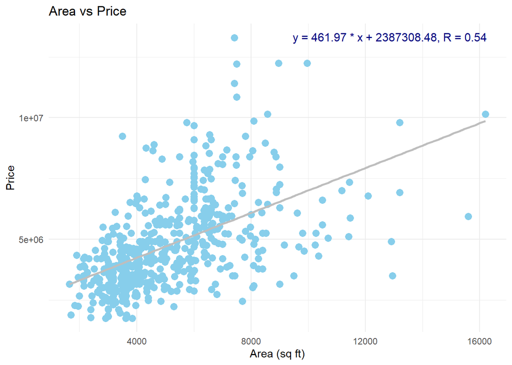

```r
library(ggplot2)

# Calculate and display R-squared for area vs price
plot_area <- ggplot(housing_data, aes(x = area, y = price)) +
  geom_point(color = "skyblue", size = 3) +  # Set color outside aes()
  geom_smooth(method = "lm", se = FALSE, color = "grey")  +  # Added grey color to trend line for clarity
  labs(title = "Area vs Price", x = "Area (sq ft)", y = "Price") +
  theme_minimal()

# Fit the linear model
model_area <- lm(price ~ area, data = housing_data)

# Calculate correlation coefficient
correlation <- cor(housing_data$price, housing_data$area)

# Extract coefficients
intercept <- coef(model_area)[1]
slope <- coef(model_area)[2]

# Create annotation text
eqn_text <- sprintf("y = %.2f * x + %.2f, R = %.2f", slope, intercept, correlation)

# Add equation and correlation coefficient to the plot
plot_area <- plot_area +
  annotate("text", x = Inf, y = Inf, label = eqn_text, hjust = 1.1, vjust = 2, size = 4, color = "navy")

# Display the plot
print(plot_area)
```

Escala logaritmica

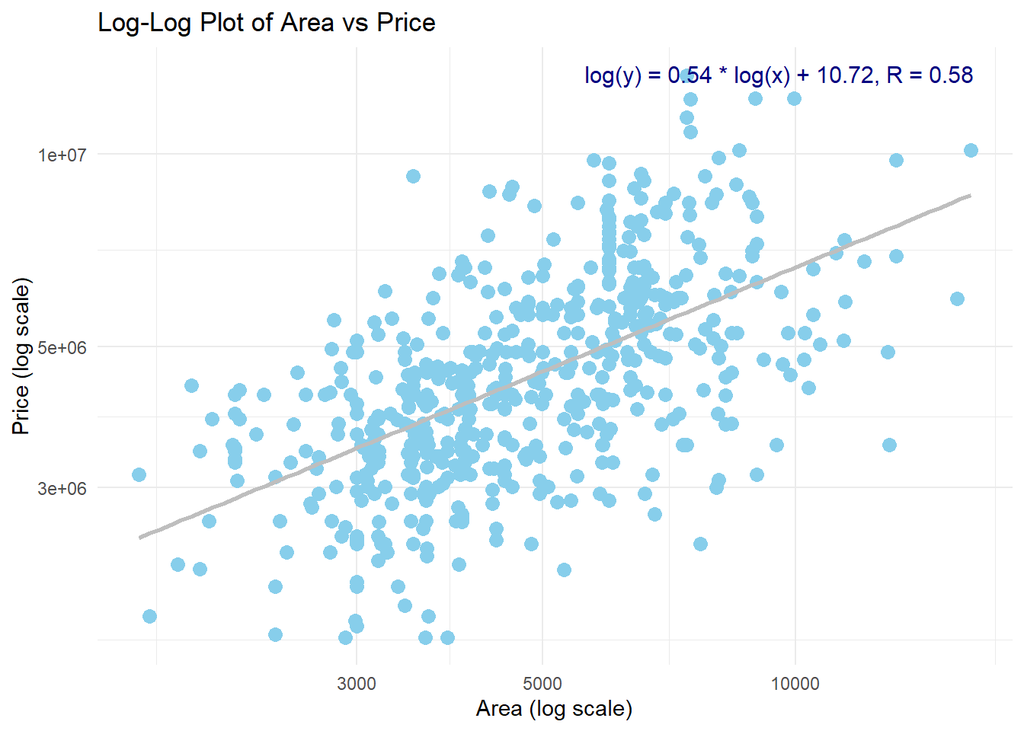

```r
library(ggplot2)

# Log-transform the data for the model
housing_data$log_price <- log(housing_data$price)
housing_data$log_area <- log(housing_data$area)

# Calculate and display the correlation coefficient for log(area) vs log(price)
plot_area_log <- ggplot(housing_data, aes(x = area, y = price)) +
  geom_point(color = "skyblue", size = 3) +  # Set color outside aes()
  geom_smooth(method = "lm", se = FALSE, color = "grey")  +  # Added red color to trend line for clarity
  labs(title = "Log-Log Plot of Area vs Price", x = "Area (log scale)", y = "Price (log scale)") +
  scale_x_log10() +  # Logarithmic scale for x-axis
  scale_y_log10() +  # Logarithmic scale for y-axis
  theme_minimal()

# Fit the linear model on log-transformed data
model_area_log <- lm(log_price ~ log_area, data = housing_data)

# Calculate correlation coefficient
correlation_log <- cor(housing_data$log_price, housing_data$log_area)

# Extract coefficients
intercept_log <- coef(model_area_log)[1]
slope_log <- coef(model_area_log)[2]

# Create annotation text
eqn_text_log <- sprintf("log(y) = %.2f * log(x) + %.2f, R = %.2f", slope_log, intercept_log, correlation_log)

# Add equation and correlation coefficient to the plot
plot_area_log <- plot_area_log +
  annotate("text", x = Inf, y = Inf, label = eqn_text_log, hjust = 1.1, vjust = 2, size = 4, color = "navy")

# Display the plot
print(plot_area_log)
```

### Rango Intercuartílico (IQR)

El Rango Intercuartílico (IQR) es una medida de dispersión estadística, que representa la amplitud de los datos. Se calcula como la diferencia entre el tercer cuartil (Q3) y el primer cuartil (Q1). Los cuartiles dividen un conjunto de datos ordenados en cuatro partes iguales.

- **Q1 (Primer Cuartil)**: El percentil 25, lo que significa que el 25% de los datos está por debajo de este valor.
- **Q3 (Tercer Cuartil)**: El percentil 75, lo que significa que el 75% de los datos está por debajo de este valor.

**Fórmula**: IQR = Q3 - Q1

**Uso del IQR**: El IQR se usa a menudo para detectar valores atípicos. Normalmente, cualquier punto de datos por debajo de Q1 - 1.5 * IQR o por encima de Q3 + 1.5 * IQR se considera un valor atípico.

**Ejemplo de Cálculo**: Supongamos que tienes los siguientes datos: 1, 2, 3, 4, 5, 6, 7, 8, 9, 10 - Primer Cuartil (Q1): El percentil 25, que es 3. - Tercer Cuartil (Q3): El percentil 75, que es 8. - IQR = Q3 - Q1 = 8 - 3 = 5

```r
# Load necessary library
library(dplyr)

# Calculate IQR for price and area
Q1_price <- quantile(housing_data$price, 0.25)
Q3_price <- quantile(housing_data$price, 0.75)
IQR_price <- Q3_price - Q1_price

Q1_area <- quantile(housing_data$area, 0.25)
Q3_area <- quantile(housing_data$area, 0.75)
IQR_area <- Q3_area - Q1_area

# Filter out outliers
housing_data_filtered <- housing_data %>%
  filter(price > (Q1_price - 1.5 * IQR_price) & price < (Q3_price + 1.5 * IQR_price)) %>%
  filter(area > (Q1_area - 1.5 * IQR_area) & area < (Q3_area + 1.5 * IQR_area))
```

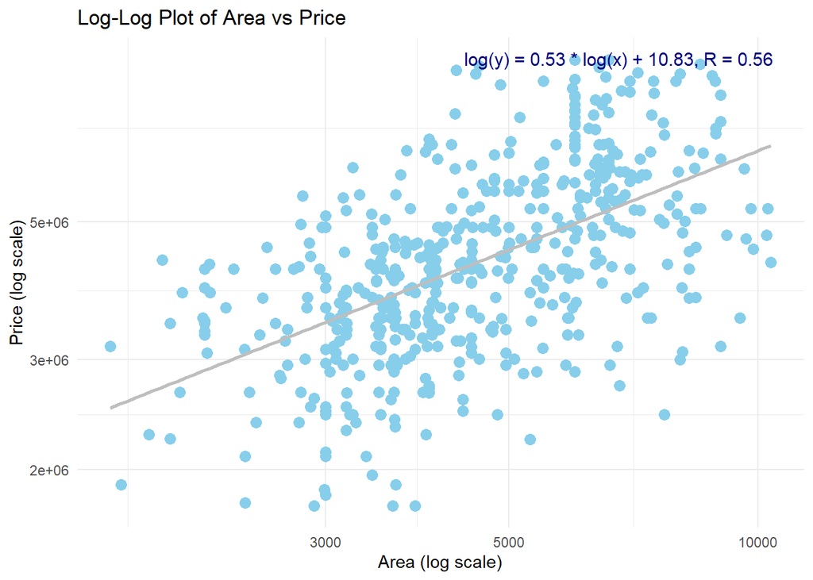

```r
library(ggplot2)

housing_data <- housing_data_filtered

# Log-transform the data for the model
housing_data$log_price <- log(housing_data$price)
housing_data$log_area <- log(housing_data$area)

# Calculate and display the correlation coefficient for log(area) vs log(price)
plot_area_log <- ggplot(housing_data, aes(x = area, y = price)) +
  geom_point(color = "skyblue", size = 3) +  # Set color outside aes()
  geom_smooth(method = "lm", se = FALSE, color = "grey")  +  # Added red color to trend line for clarity
  labs(title = "Log-Log Plot of Area vs Price", x = "Area (log scale)", y = "Price (log scale)") +
  scale_x_log10() +  # Logarithmic scale for x-axis
  scale_y_log10() +  # Logarithmic scale for y-axis
  theme_minimal()

# Fit the linear model on log-transformed data
model_area_log <- lm(log_price ~ log_area, data = housing_data)

# Calculate correlation coefficient
correlation_log <- cor(housing_data$log_price, housing_data$log_area)

# Extract coefficients
intercept_log <- coef(model_area_log)[1]
slope_log <- coef(model_area_log)[2]

# Create annotation text
eqn_text_log <- sprintf("log(y) = %.2f * log(x) + %.2f, R = %.2f", slope_log, intercept_log, correlation_log)

# Add equation and correlation coefficient to the plot
plot_area_log <- plot_area_log +
  annotate("text", x = Inf, y = Inf, label = eqn_text_log, hjust = 1.1, vjust = 2, size = 4, color = "navy")

# Display the plot
print(plot_area_log)
```